# Tipologia y ciclo de vida de los datos - PRA2

Una vez comprobada la normalidad de los datos, comentaremos el análisis de la varianza.

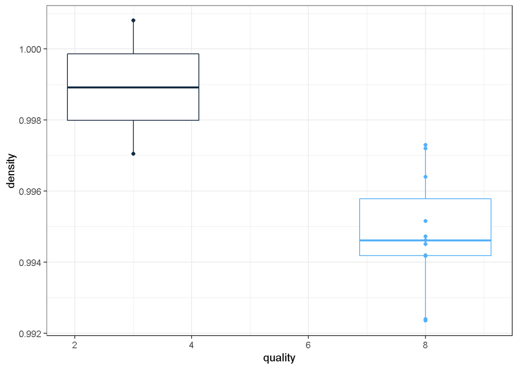

```r
# Visualización de las distribuciones de datos de densidad en función de la calidad del vino.
calidad <- filter(.data = datos_clean, quality %in% c("3", "8"))
ggplot(data = calidad, aes(x = quality, y = density, colour = quality, group=quality)) +
  geom_boxplot() +
  geom_point() +
  theme_bw() +
  theme(legend.position = "none")
```

```r
# Test que nos permite comprobar si se observan diferencias estadísticamente significativas de la densidad entre vinos de diferentes calidades escogidos.
t.test(density ~ quality, data = calidad)
```

```
##
##  Welch Two Sample t-test
##
## data:  density by quality
## t = 2.1158, df = 1.1459, p-value = 0.2552
## alternative hypothesis: true difference in means is not equal to 0
## 95 percent confidence interval:
##  -0.01423867  0.02244867
## sample estimates:
## mean in group 3 mean in group 8
##        0.998925        0.994820
```

En este caso tenemos un valor de p-value mayor al nivel de significancia, lo que significa que no se observan diferencias estadísticamente significativas entre los grupos de datos de la calidad del vino para la variable densidad. En este escenario podríamos aplicar los diferentes test para responder las preguntas que nos planteamos sobre este subconjunto de datos.

Nuestro objetivo es la predicción de la calidad del vino con los diferentes parámetros de sus componentes, por lo que que vamos a proseguir con el análisis de correlación de los datos.